# Classification Algorithm - Processing

Jae Kwan Koo

## Library

```r
# manupulate
library(tidyverse)
library(data.table)

# modeling
library(caret)
```

## DATA - mdrr

```r
data(mdrr)

table(mdrrDescr$nR11) %>% data.frame
```

```
##   Var1 Freq
## 1    0  501
## 2    1    4
## 3    2   23
```

mdrr 데이터는 다중약물내성 자료(528개 관측치, 342개 변수)이다.  
`data(mdrr)`을 통해 mdrrDescr데이터를 import하였고, 이 데이터로부터 nR11변수의 값들을 frequency별로 확인하였다.

### 0에 가까운 분산

변수를 선택하는 기법 중 가장 단순한 방법은 변숫값의 분산을 보는 것이다.  
예를 들어, 데이터 1,000개가 있는데 이 중 990개에서 변수 A의 값이 0, 10개에서 변수 A의 값이 1이라고 하자. 그러면 변수 A는 서로 다른 관찰을 구분하는 데 별 소용이 없다. 따라서 데이터 모델링에서도 그리 유용하지 않다.

이런 변수는 분산이 0에 가까우며, caret 패키지에서는 `nearZeroVar()` 함수를 사용해 이런 변수들을 쉽게 제거할 수 있게 해주고 있다.

- 정리!
  - 일부 상황에서 데이터 생성 메커니즘은 한 개의 값만을 취하는(영-분산)예측변수를 생성할 수 있다.
  - 많은 모형(트리 기반 모델 제외)에서, 영-분산 예측변수는 모형을 망가뜨리거나 불안정한 적합의 원인
  - 마찬가지로 예측변수는 매우 낮은 빈도로 발생하는 몇 개의 값만을 취할 수도 있다.
  - 영근처-분산 예측변수는 모형화 이전에 식별되고 제거되어야 한다.
- 영-분산 예측변수 또는 영근처-분산 예측변수를 식별하기 위한 두 가지 측도
  - `빈도 비율(frequency ratio)` : (가장 많이 발생한 빈도) / (두번째 많은 발생 빈도)
  - `유일 값들(unique values)` : (유일한 값들의 수) / (전체 표본 수)

`유일값들`은 데이터가 세분화가 증가함에 따라 0에 가까워진다. 우리가 설정한 임계값보다 낮으면 예측변수가 영-분산에 가깝다고 간주할 수 있다.

```r
nzv_df <- nearZeroVar(mdrrDescr, saveMetrics = T)

head(nzv_df)
```

```
##     freqRatio percentUnique zeroVar   nzv
## MW      1.250      89.96212   FALSE FALSE
## AMW     1.125      42.61364   FALSE FALSE
## Sv      1.000      82.95455   FALSE FALSE
## Se      1.250      84.28030   FALSE FALSE
## Sp      1.250      82.76515   FALSE FALSE
## Ss      1.000      71.21212   FALSE FALSE
```

`nearZeroVar()`로 할당된 nzv_df의 rownames는 mdrrDescr의 변수이름들을 나열한 것이다.  
**saveMetrics = T**로 두게 되면 dataframe의 형태를 얻을 수 있는데, 위 표에서 nzv 컬럼은 Near Zero Variance를 뜻하므로, nzv 컬럼에 TRUE로 표시된 변수들을 제거하면 된다.

- How?
  - nearZeroVar() 함수의 호출시saveMetrics=T 옵션을 사용하면 각 예측값에 대한 빈도비율(freqRatio)과 유일 값들의 비율(percentUnique)을 얻을 수 있으며, 동시에 각 변수가 영-분산 또는 영-근처 분산을 가지는지를 알려준다.
  - 디폴트로, 표본에서 유일 값의 비율이10% 이하이고 빈도비율이 19(95/5)보다 큰 예측변수는 영-근처 분산으로 분류. 디폴트 값들은 **uniqueCut=** 과 **freqCut=** 옵션을 통해 변경될 수 있다.

```r
nzv_index <- nearZeroVar(mdrrDescr)   # nearZeroVar(mdrrDescr, saveMetrics = F),  F is default
nzv_index
```

```
##  [1]  22  31  32  34  38  41  42 259 262 263 264 266 267 270 271 272 273
## [18] 274 276 277 278 279 280 281 282 283 284 285 286 287 288 327 328 330
## [35] 331 333 334 335 336 337 338 339 340 341 342
```

```r
filteredDescr <- mdrrDescr[, -nzv_index]
dim(filteredDescr)
```

```
## [1] 528 297
```

`nearZeroVar()` 호출 시 **saveMetrics**를 지정하지 않으면 분산이 0에 가까운 변수에 해당하는 컬럼 번호를 곧바로 출력해준다. 따라서 이를 사용해 손쉽게 분산이 0에 가까운 컬럼들을 제거할 수 있다.

- filterredDescr는 분산이 0에 가까운 변수들을 기존 mdrrDescr으로부터 제거한 dataset이다.

### 상관된 예측변수의 식별 : 중복변수 제거

※상관계수

변수 간 높은 상관 계수가 존재한다는 것은 두 변수가 같이 커지거나 작아지는 경향이 있다는 의미다. 선형 모델, 신경망 등의 기계 학습 모델은 상관 계수가 큰 예측 변수들이 있을 경우 성능이 떨어지거나 모델이 불안정해진다. 또, 기계 학습이란 결국 모델의 파라미터를 측정하는 작업인데, 상관 계수가 높은 변수가 여럿 존재하면 파라미터 수가 불필요하게 증가하여 차원 저주에 빠질 우려가 있다.  
상관관계가 높은 변수들이 있다면 이들을 주성분 분석과 같은 방법을 사용해 서로 독립된 차원으로 변환하거나, 상관 계수가 큰 변수들을 제거해 버릴 수 있다.  
caret의 `findCorrelation()`의 동작 방식은 다음과 같다.

1. 상관 계수 행렬을 입력으로 받아 **상관 계수가 cutoff를 넘는 변수 쌍 A, B**를 찾는다.
2. A와 B 중 둘을 제외한 다른 변수와의 상관 계수가 큰 변수 하나를 삭제한다.
3. 1 ~ 2를 계속 반복하면서 상관 계수가 높은 변수들을 제거해나간다.

코드화된 과정은 아래와 같다.

[output not shown]

먼저 그냥 상관계수의 절댓값이 0.999로 매우 높은 상관관계가 있는 컬럼 갯수를 확인했다.  
그냥 이렇구나 하고 아래 두 과정을 비교해보자.

#### Before processing

```r
descrCor <- cor(filteredDescr)

summary(descrCor[upper.tri(descrCor)])
```

```
##     Min.  1st Qu.   Median     Mean  3rd Qu.     Max.
## -0.99607 -0.05373  0.25006  0.26078  0.65527  1.00000
```

일단 전처리를 하기 전의 상관관계들의 summary이다.

#### After Processing

```r
highlyCorDescr <- findCorrelation(descrCor, cutoff = 0.75)

highlyCorDescr
```

```
##   [1]   5  11  12  13  14  16  23  24  30  37  38  39  40  42  43  44  45
##  [18]  47  49  50  51  52  53  55  56  57  58  59  61  62  63  64  65  66
##  [35]  68  69  70  71  72  73  74  75  76  77  78  79  83  84  85  88  90
##  [52]  91  92  93  94  95  96  97  98  99 100 101 102 103 104 105 106 110
##  [69] 111 112 113 114 115 116 117 118 119 120 121 122 123 124 125 126 127
##  [86] 132 134 135 136 137 138 139 140 141 144 145 146 148 149 150 152 153
## [103] 154 155 156 157 158 159 160 161 162 164 165 167 169 170 172 174 175
## [120] 176 177 178 179 180 181 182 183 184 185 186 187 189 190 191 192 193
## [137] 194 195 196 197 198 199 200 202 204 205 206 207 208 209 210 211 212
## [154] 213 214 215 216 217 218 219 220 221 222 223 224 225 226 227 228 229
## [171] 230 231 232 233 234 235 236 237 238 239 240 246 249 250 251 252 253
## [188] 254 258 259 261 262 263 265 266 267 274 277 278 279 280 281 282 284
## [205] 285 286 287 288 289 290 293 294 295 296   1   3   4   7   8  17  19
## [222]  15   6  20  41  80  81  18 108 109  54 163 166 168 171 147 241 242
## [239] 243 244 247  25  26  67 270 255 256
```

0.75기준으로 위의 n번째 컬림의 상관계수가 높은 것으로 나타났다.

```r
filteredDescr <- filteredDescr[, -highlyCorDescr]
descrCor2 <- cor(filteredDescr)

summary(descrCor2[upper.tri(descrCor2)])
```

```
##     Min.  1st Qu.   Median     Mean  3rd Qu.     Max.
## -0.70728 -0.05378  0.04418  0.06692  0.18858  0.74458
```

이 높은 컬럼을 기존 데이터에서 삭제한 뒤 다시 상관계수들의 summary를 통해 분포를 확인해본다.

#### Compare Before one with After one

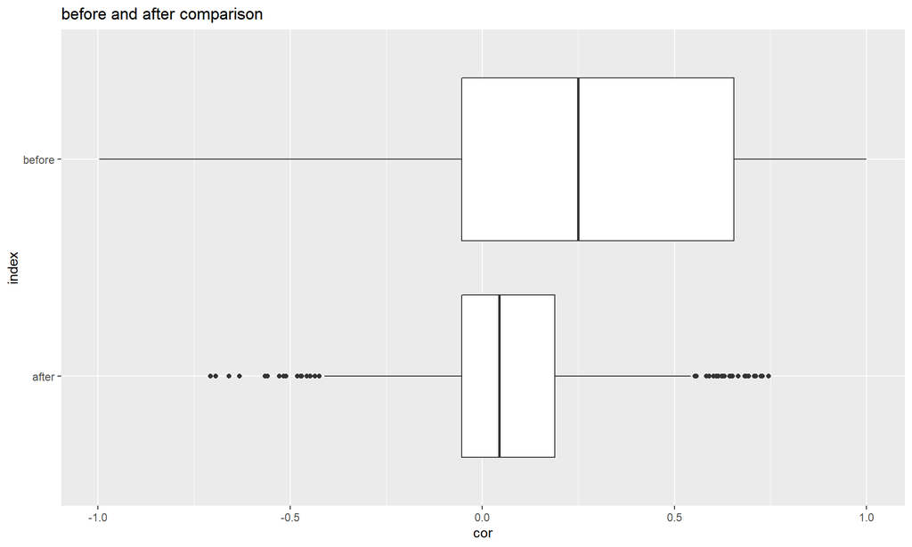

```r
before <- data.frame(cor = descrCor[upper.tri(descrCor)])
after <- data.frame(cor = descrCor2[upper.tri(descrCor2)])

before["index"] <- "before"; after["index"] <- "after"

compare_dat <- rbind(before, after)


compare_dat %>% ggplot(aes(x = cor, y = index)) +
  geom_boxplot() + ggtitle("before and after comparison")
```

after processing에서 절댓값0.75이후의 양쪽의 상관계수들은 cut-off된 것을 확인할 수 있다.

### 예측변수의 변환

#### 중심화와 척도화

**`preProcess()`**  
* 중심화(centrering)와 척도화(scaling)을 포함하여 예측변수에 대해 많은 연산을 제공  
* 각 연산에 필요한 매개 변수를 추정  
* 특정데이터셋(예를들어, 훈련용자료)으로부터 요구하는 것을 추정한 다음, 이 값을 재계산 하지않고 임의의 데이터세트에 이들변환을 적용  
* 실제로 데이터를 전처리하지 않음  
* `train()`함수를 호출 할 때, 인터페이스가 될 수도 있음  
* `method = "ranges"`옵션은 0과 1사이의 값으로 데이터를 변환

**`predict.preProcess()`**  
* 특정 데이터 집합에 이를 적용하는데 사용  
* 데이터셋(훈련용)과 다른 데이터셋(검증용)을 전처리하는데 사용

```r
set.seed(200)
inTrain <- sample(seq(along = mdrrClass), length(mdrrClass)/2)

training <- filteredDescr[inTrain, ]
test <- filteredDescr[-inTrain, ]

trainMDRR <- mdrrClass[inTrain]
testMDRR <- mdrrClass[-inTrain]
```

mdrrClass데이터는 Active와 Inactive의 2 클래스를 가지는 factor들과 대응된다.(data를 import할 때, mdrrClass와 mdrrDescr데이터는 같이 import됨)

```r
# 중심화, 척도화
preProcValues <- preProcess(training, method = c("center","scale"))

trainTransformed <- predict(preProcValues, training)
testTransformed <- predict(preProcValues, test)

preProcValues
```

```
## Created from 264 samples and 50 variables
##
## Pre-processing:
##   - centered (50)
##   - ignored (0)
##   - scaled (50)
```

#### 박스-콕스 변환

- preprocess()함수에서 method = “BoxCox”옵션은 예측변수에 대한 박스-콕스 변환의 차수를 추정(데이터가 0보다 큰 경우에 한함)
- NA값은 변환될 수 없는 예측인자에 해당
- 데이터가 0보다 커야함
- 두 가지 유사한 변형으로, Yeo-Johnson과 Manly(1976)의 지수변환이 preProcess()함수에 사용될 수 있음

```r
# Box-Cox transformation
preProcValues2 <- preProcess(training, method = "BoxCox")

trainBC <- predict(preProcValues2, training)
testBC <- predict(preProcValues2, test)

preProcValues2
```

```
## Created from 264 samples and 31 variables
##
## Pre-processing:
##   - Box-Cox transformation (31)
##   - ignored (0)
##
## Lambda estimates for Box-Cox transformation:
##    Min. 1st Qu.  Median    Mean 3rd Qu.    Max.
## -2.0000 -0.2500  0.4000  0.4548  1.4500  2.0000
```

## Refer

- 0에 가까운 분산, 상관계수  
  https://medium.com/@hslee09/r-%EB%B6%84%EB%A5%98-%EC%95%8C%EA%B3%A0%EB%A6%AC%EC%A6%98-%EC%A0%84%EC%B2%98%EB%A6%AC-d22feb413b17
- Pre-Processing using `caret` package  
  https://topepo.github.io/caret/pre-processing.html